# Full Fairfax Profiling

## First 6 Variables

Table for completeness of Variables

```
## [1] "first_six"
```

| set | column | blanks | true_na | written_na | percent_complete | unique_values |
| --- | --- | --- | --- | --- | --- | --- |
| first_six | PARCEL_ID | 0 | 0 | 0 | 1.0000000 | 332067 |
| first_six | NUM_UNITS | 0 | 0 | 0 | 1.0000000 | 249 |
| first_six | HOUSING_TYPE | 0 | 0 | 0 | 1.0000000 | 8 |
| first_six | YEAR_BUILT | 0 | 453 | 0 | 0.9986363 | 184 |
| first_six | LONGITUDE | 0 | 0 | 0 | 1.0000000 | 282444 |
| first_six | LATITUDE | 0 | 0 | 0 | 1.0000000 | 282444 |

General exploration of the first 6 variables

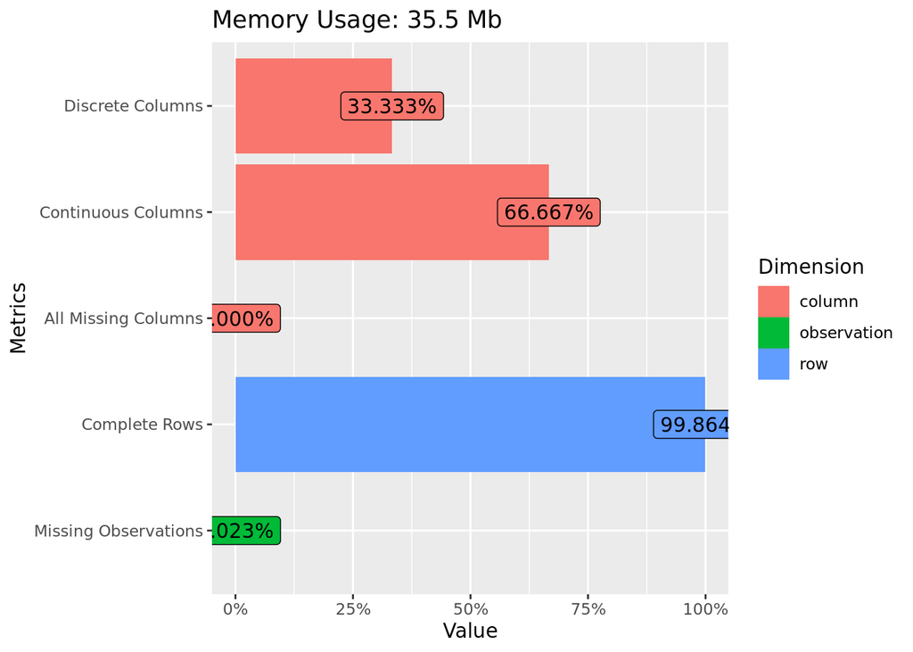

Distribution of Housing Type Variable

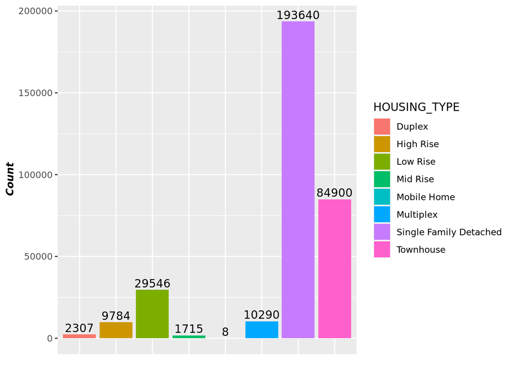

Distribution of the year houses were built in

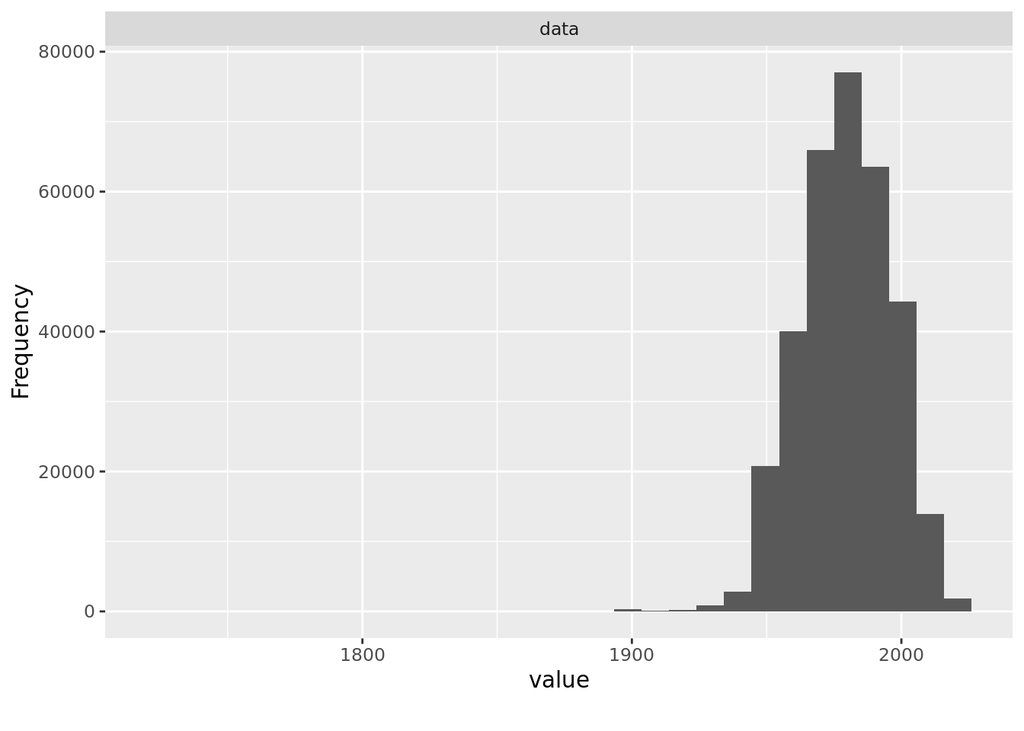

Distribution of the number of units

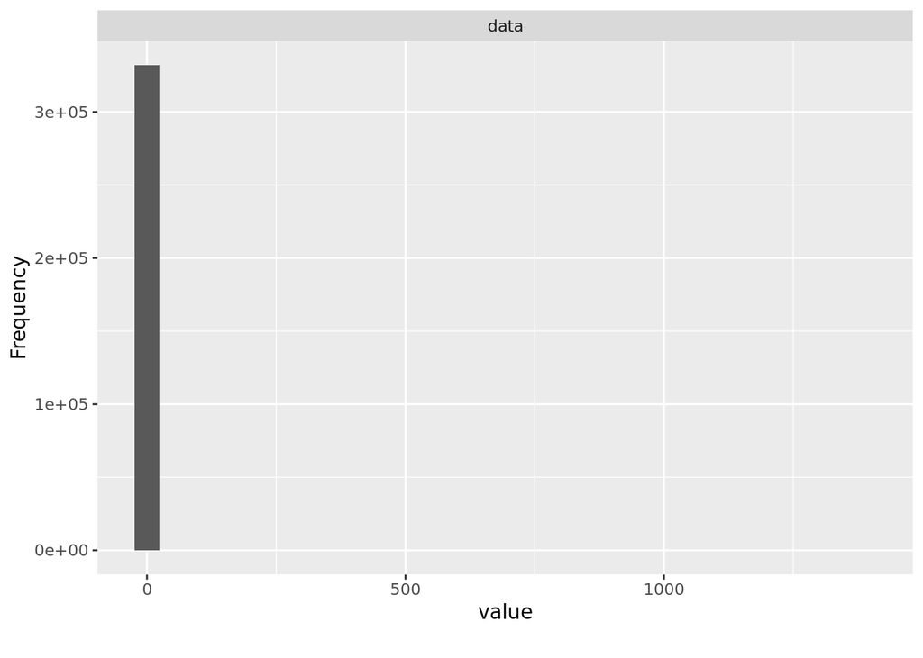

Number of units built per year

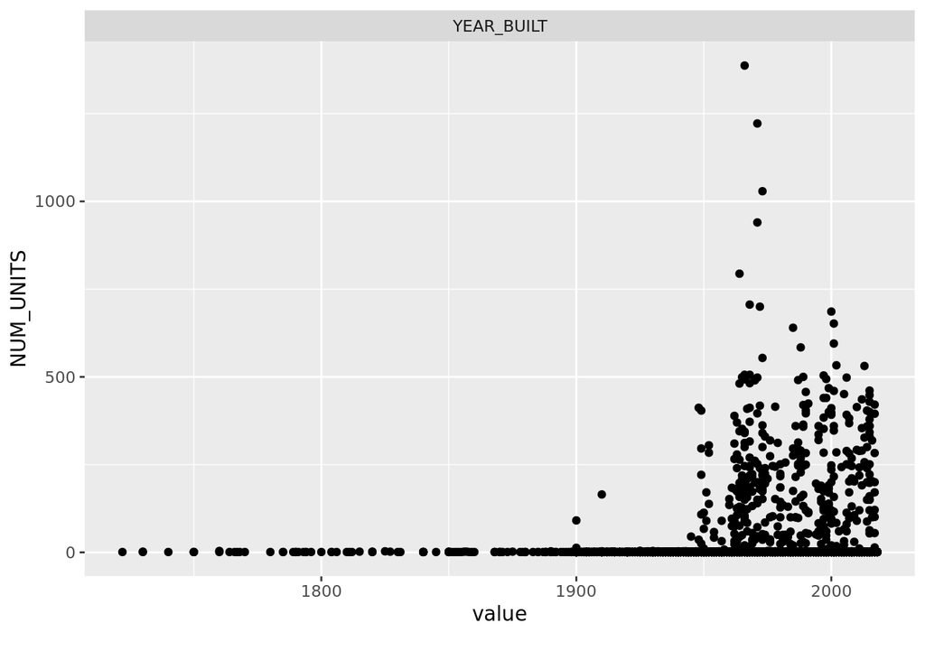

## Second 6 Variables

Profiling fairfax data, specifically the variables WATER, SEWER, GAS, VALUE_LAND, VALUE_BUILDING, & VALUE_TOTAL.

```
## [1] "select(fairfax_housing_2018_geo, 7:12)"
```

| set | column | blanks | true_na | written_na | percent_complete | unique_values |
| --- | --- | --- | --- | --- | --- | --- |
| select(fairfax_housing_2018_geo, 7:12) | WATER | 0 | 2710 | 0 | 0.9918420 | 4 |
| select(fairfax_housing_2018_geo, 7:12) | SEWER | 0 | 2327 | 0 | 0.9929950 | 4 |
| select(fairfax_housing_2018_geo, 7:12) | GAS | 0 | 4308 | 0 | 0.9870315 | 4 |
| select(fairfax_housing_2018_geo, 7:12) | VALUE_LAND | 0 | 2218 | 0 | 0.9933231 | 2215 |
| select(fairfax_housing_2018_geo, 7:12) | VALUE_BUILDING | 0 | 2218 | 0 | 0.9933231 | 62229 |
| select(fairfax_housing_2018_geo, 7:12) | VALUE_TOTAL | 0 | 2218 | 0 | 0.9933231 | 86831 |

Trying out DataExplorer package.

```
## # A tibble: 1 x 9
##     rows columns discrete_columns continuous_colu… all_missing_col…
##    <int>   <int>            <int>            <int>            <int>
## 1 332190      18                7               11                0
## # … with 4 more variables: total_missing_values <int>, complete_rows <int>,
## #   total_observations <int>, memory_usage <dbl>
```

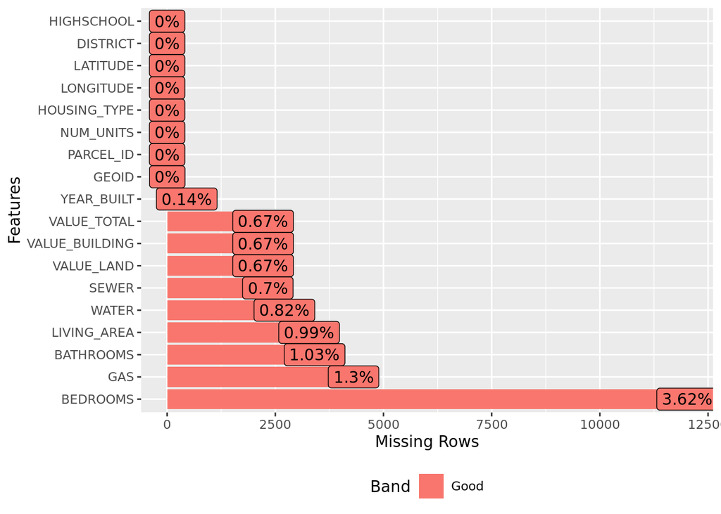

Plotting frequencies for categorical variables WATER, SEWER, and GAS.

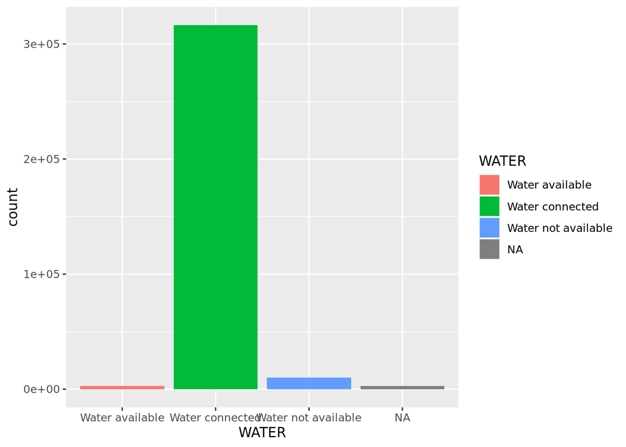

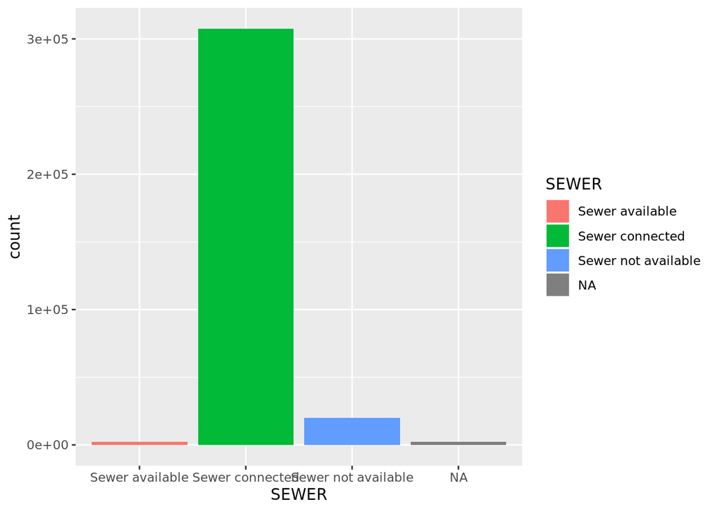

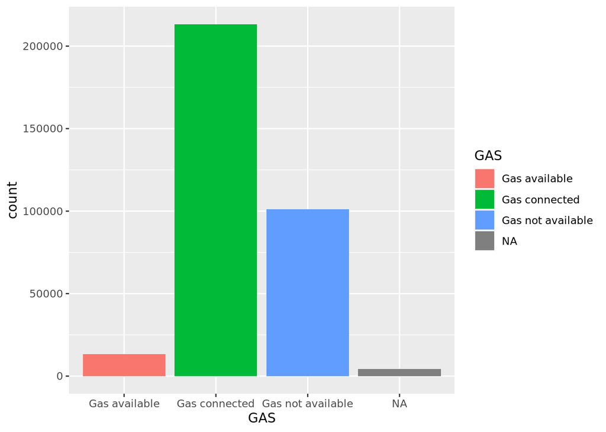

Looking at value distributions. Lowest and highest 1% are removed.

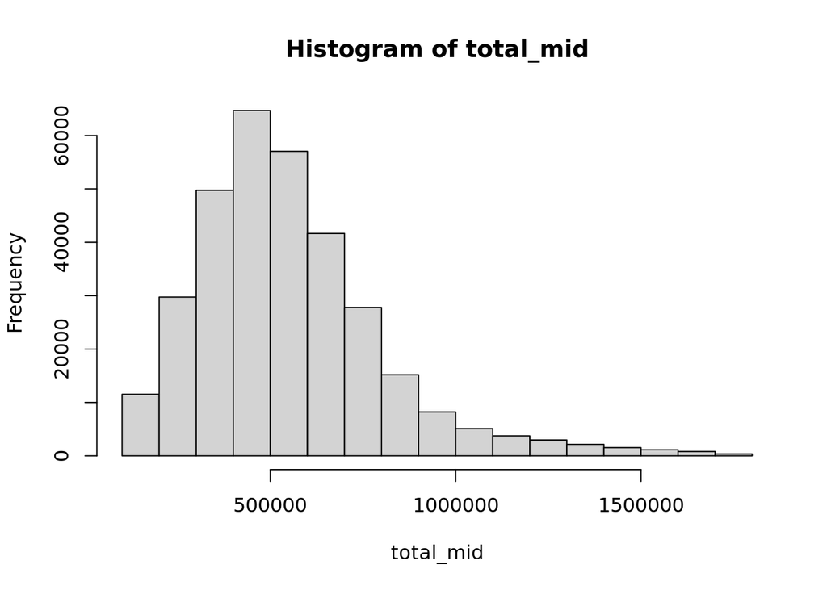

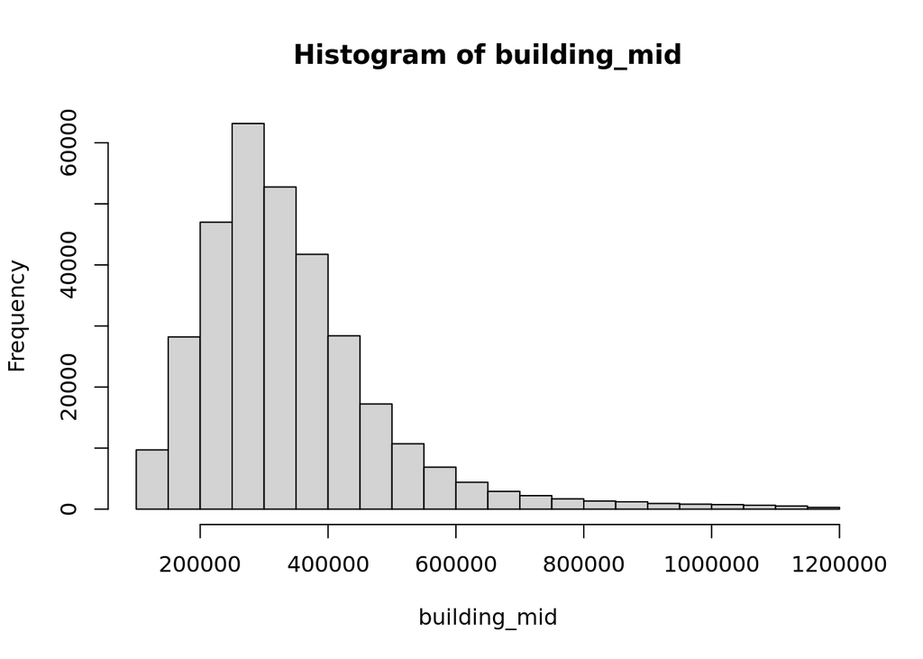

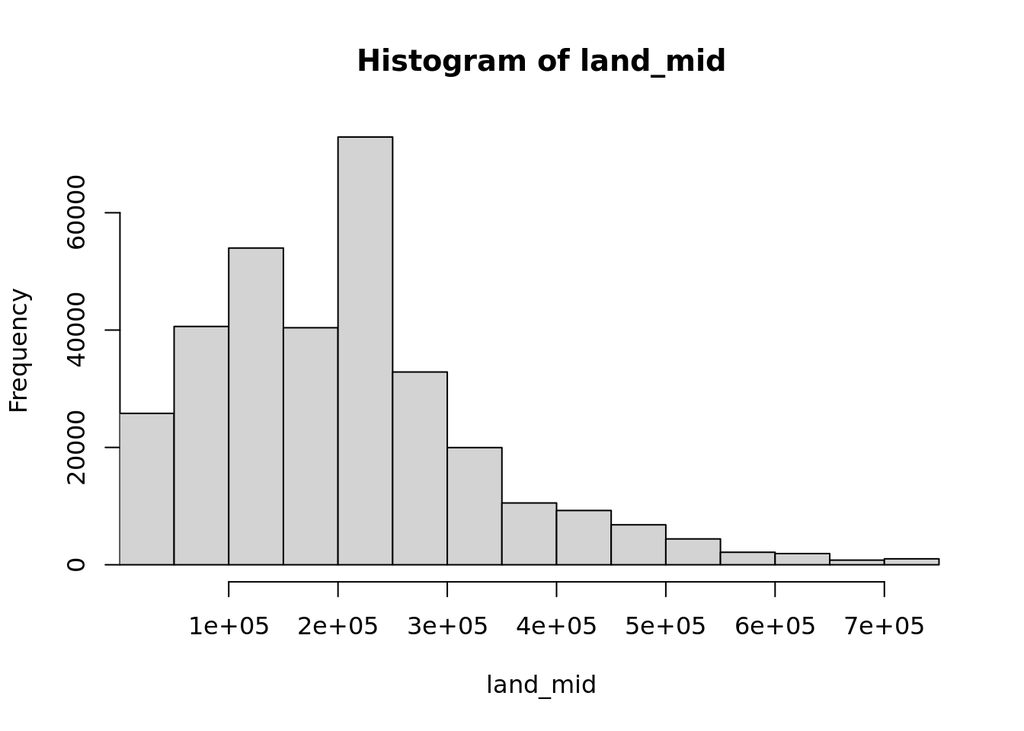

Quick check to see if VALUE_LAND and VALUE_BUILDING sum to VALUE_TOTAL.

```
## [1] 203175855193
```

```
## [1] 203175855193
```

## Final 6 Variables

We use a custom function to check for completion of the six variables in question. The results are below:

```
## [1] "d_six"
```

| set | column | blanks | true_na | written_na | percent_complete | unique_values |
| --- | --- | --- | --- | --- | --- | --- |
| d_six | BEDROOMS | 0 | 12017 | 0 | 0.9638249 | 15 |
| d_six | BATHROOMS | 0 | 3408 | 0 | 0.9897408 | 16 |
| d_six | LIVING_AREA | 0 | 3281 | 0 | 0.9901231 | 7240 |
| d_six | GEOID | 0 | 3 | 0 | 0.9999910 | 646 |
| d_six | DISTRICT | 0 | 0 | 0 | 1.0000000 | 9 |
| d_six | HIGHSCHOOL | 0 | 0 | 0 | 1.0000000 | 24 |

We confirm these results for the full data:

```
## [1] "d_full"
```

| set | column | blanks | true_na | written_na | percent_complete | unique_values |
| --- | --- | --- | --- | --- | --- | --- |
| d_full | PARCEL_ID | 0 | 0 | 0 | 1.0000000 | 332067 |
| d_full | NUM_UNITS | 0 | 0 | 0 | 1.0000000 | 249 |
| d_full | HOUSING_TYPE | 0 | 0 | 0 | 1.0000000 | 8 |
| d_full | YEAR_BUILT | 0 | 453 | 0 | 0.9986363 | 184 |
| d_full | LONGITUDE | 0 | 0 | 0 | 1.0000000 | 282444 |
| d_full | LATITUDE | 0 | 0 | 0 | 1.0000000 | 282444 |
| d_full | WATER | 0 | 2710 | 0 | 0.9918420 | 4 |
| d_full | SEWER | 0 | 2327 | 0 | 0.9929950 | 4 |
| d_full | GAS | 0 | 4308 | 0 | 0.9870315 | 4 |
| d_full | VALUE_LAND | 0 | 2218 | 0 | 0.9933231 | 2215 |
| d_full | VALUE_BUILDING | 0 | 2218 | 0 | 0.9933231 | 62229 |
| d_full | VALUE_TOTAL | 0 | 2218 | 0 | 0.9933231 | 86831 |
| d_full | BEDROOMS | 0 | 12017 | 0 | 0.9638249 | 15 |
| d_full | BATHROOMS | 0 | 3408 | 0 | 0.9897408 | 16 |
| d_full | LIVING_AREA | 0 | 3281 | 0 | 0.9901231 | 7240 |
| d_full | GEOID | 0 | 3 | 0 | 0.9999910 | 646 |
| d_full | DISTRICT | 0 | 0 | 0 | 1.0000000 | 9 |
| d_full | HIGHSCHOOL | 0 | 0 | 0 | 1.0000000 | 24 |

We confirm these results for the six variables in question using the DataExplorer package:

```
## # A tibble: 1 x 9
##     rows columns discrete_columns continuous_colu… all_missing_col…
##    <int>   <int>            <int>            <int>            <int>
## 1 332190       6                2                4                0
## # … with 4 more variables: total_missing_values <int>, complete_rows <int>,
## #   total_observations <int>, memory_usage <dbl>
```

We plot the missing values of the six variables in question to see proportions:

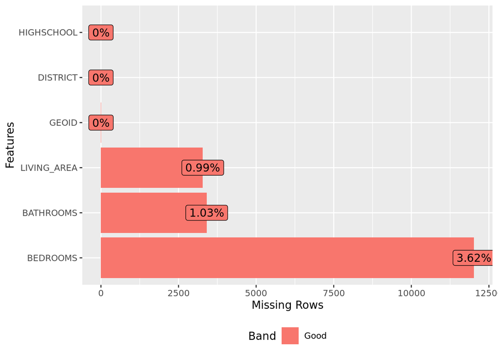

We plot the continuous variables:

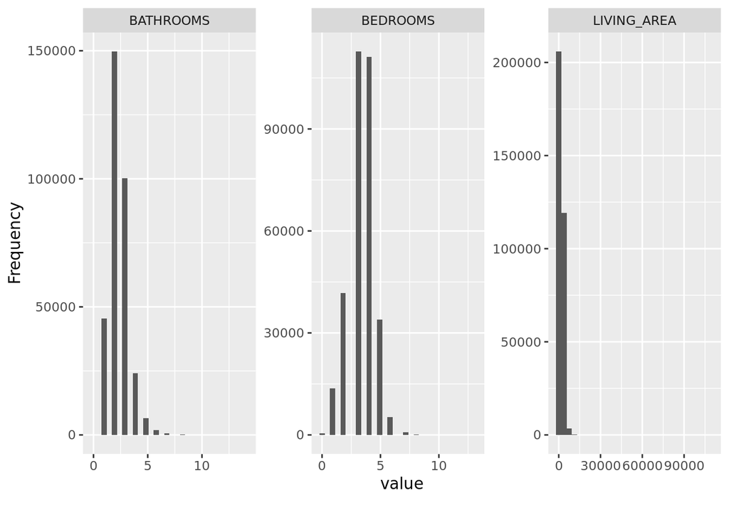

To read the continuous variables better we plot them individually:

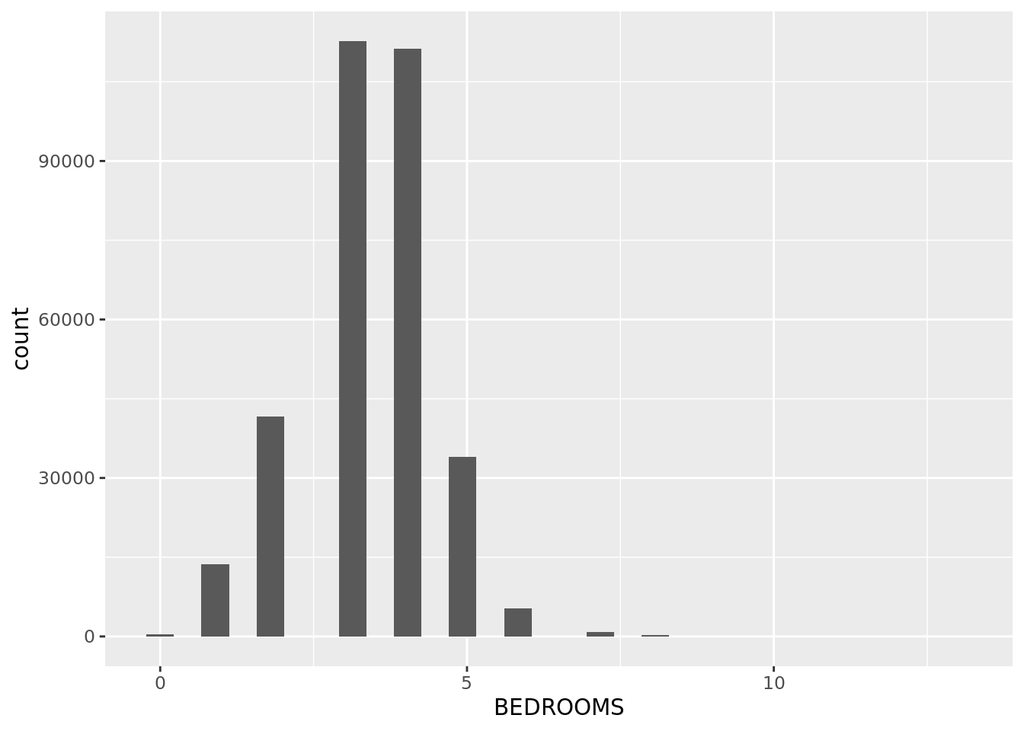

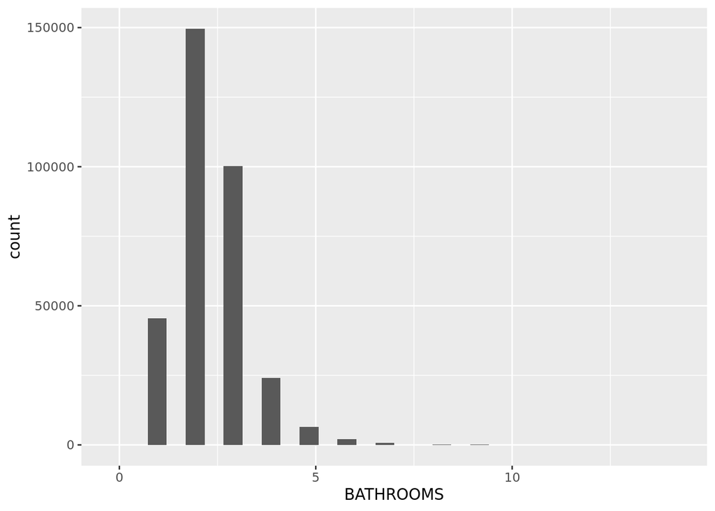

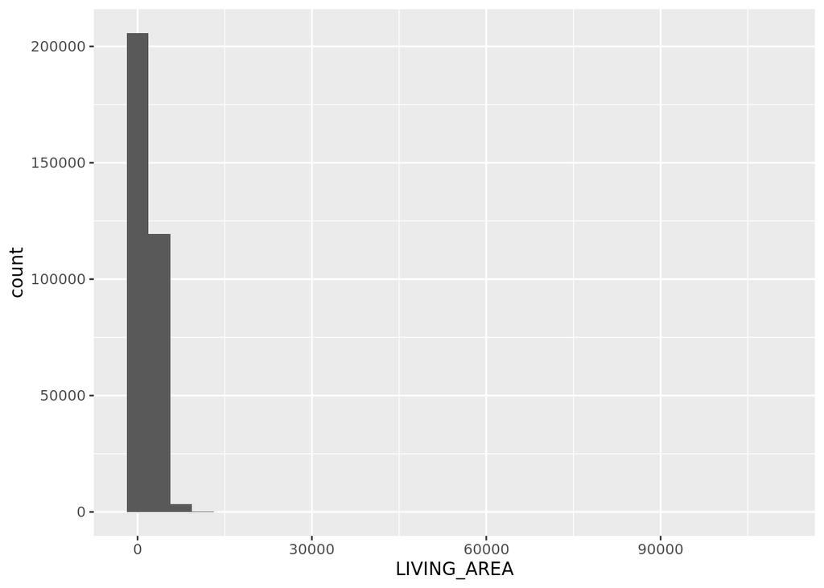

We plot the categorical variables:

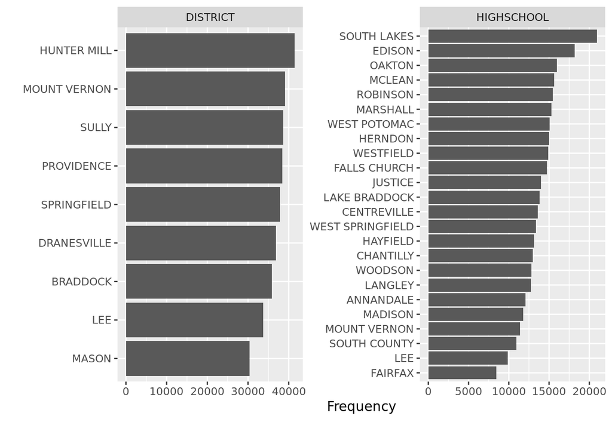